> *Analysis of how chemical properties influence the quality of red wines by Meixian Chen*

> **Introduction**: This report uses R to quatitatively analyze how chemical properties influence the quality of red wines. The tidy wine data consist of 1599 red wines with 11 variables on the chemical properties of the wine. Each wine is rated by at least 3 wine experts, providing a rating between 0 (very bad) and 10 (very excellent).

> **Overview of the wine dataset**

> Here is part of the dataset, contains 1599 obervations of 11 chemical properties and quality ratings of wines.

```
## 'data.frame':    1599 obs. of  13 variables:
##  $ X                   : int  1 2 3 4 5 6 7 8 9 10 ...
##  $ fixed.acidity       : num  7.4 7.8 7.8 11.2 7.4 7.4 7.9 7.3 7.8 7.5 ...
##  $ volatile.acidity    : num  0.7 0.88 0.76 0.28 0.7 0.66 0.6 0.65 0.58 0.5 ...
##  $ citric.acid         : num  0 0 0.04 0.56 0 0 0.06 0 0.02 0.36 ...
##  $ residual.sugar      : num  1.9 2.6 2.3 1.9 1.9 1.8 1.6 1.2 2 6.1 ...
##  $ chlorides           : num  0.076 0.098 0.092 0.075 0.076 0.075 0.069 0.065 0.073 0.071 ...
##  $ free.sulfur.dioxide : num  11 25 15 17 11 13 15 15 9 17 ...
##  $ total.sulfur.dioxide: num  34 67 54 60 34 40 59 21 18 102 ...
##  $ density             : num  0.998 0.997 0.997 0.998 0.998 ...
##  $ pH                  : num  3.51 3.2 3.26 3.16 3.51 3.51 3.3 3.39 3.36 3.35 ...
##  $ sulphates           : num  0.56 0.68 0.65 0.58 0.56 0.56 0.46 0.47 0.57 0.8 ...
##  $ alcohol             : num  9.4 9.8 9.8 9.8 9.4 9.4 9.4 10 9.5 10.5 ...
##  $ quality             : int  5 5 5 6 5 5 5 7 7 5 ...
```

> Summary of statistics of each variables

```
##  fixed.acidity   volatile.acidity  citric.acid    residual.sugar
##  Min.   : 4.60   Min.   :0.1200   Min.   :0.000   Min.   : 0.900
##  1st Qu.: 7.10   1st Qu.:0.3900   1st Qu.:0.090   1st Qu.: 1.900
##  Median : 7.90   Median :0.5200   Median :0.260   Median : 2.200
##  Mean   : 8.32   Mean   :0.5278   Mean   :0.271   Mean   : 2.539
##  3rd Qu.: 9.20   3rd Qu.:0.6400   3rd Qu.:0.420   3rd Qu.: 2.600
##  Max.   :15.90   Max.   :1.5800   Max.   :1.000   Max.   :15.500
##    chlorides       free.sulfur.dioxide total.sulfur.dioxide
##  Min.   :0.01200   Min.   : 1.00       Min.   :  6.00
##  1st Qu.:0.07000   1st Qu.: 7.00       1st Qu.: 22.00
##  Median :0.07900   Median :14.00       Median : 38.00
##  Mean   :0.08747   Mean   :15.87       Mean   : 46.47
##  3rd Qu.:0.09000   3rd Qu.:21.00       3rd Qu.: 62.00
##  Max.   :0.61100   Max.   :72.00       Max.   :289.00
##     density             pH          sulphates         alcohol
##  Min.   :0.9901   Min.   :2.740   Min.   :0.3300   Min.   : 8.40
##  1st Qu.:0.9956   1st Qu.:3.210   1st Qu.:0.5500   1st Qu.: 9.50
##  Median :0.9968   Median :3.310   Median :0.6200   Median :10.20
##  Mean   :0.9967   Mean   :3.311   Mean   :0.6581   Mean   :10.42
##  3rd Qu.:0.9978   3rd Qu.:3.400   3rd Qu.:0.7300   3rd Qu.:11.10
##  Max.   :1.0037   Max.   :4.010   Max.   :2.0000   Max.   :14.90
##     quality
##  Min.   :3.000
##  1st Qu.:5.000
##  Median :6.000
##  Mean   :5.636
##  3rd Qu.:6.000
##  Max.   :8.000
```

# Univariate Plots Section

> Visual distribution of each variables

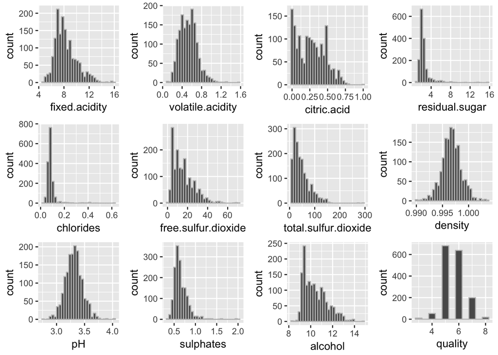

# Univariate Analysis

> We want to investgate which chemical properties affect the wine quality, and also how much they relate to each other. Here is matrix presenting the correlation values among the variables. Red color dots shows negative correlation and blue are positive correlation. The darkness and the size of the dots shows how strong is the correlation.

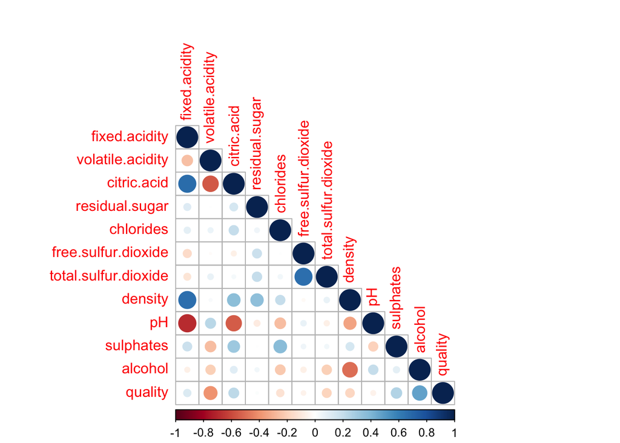

> Quaily is mainly related to alcohol and volative.acidity levels, then to citric.acid and sulphates levels.

# Bivariate Plots and Analysis Section

> We plot the quality variable with the chemical properties which highly related to it.

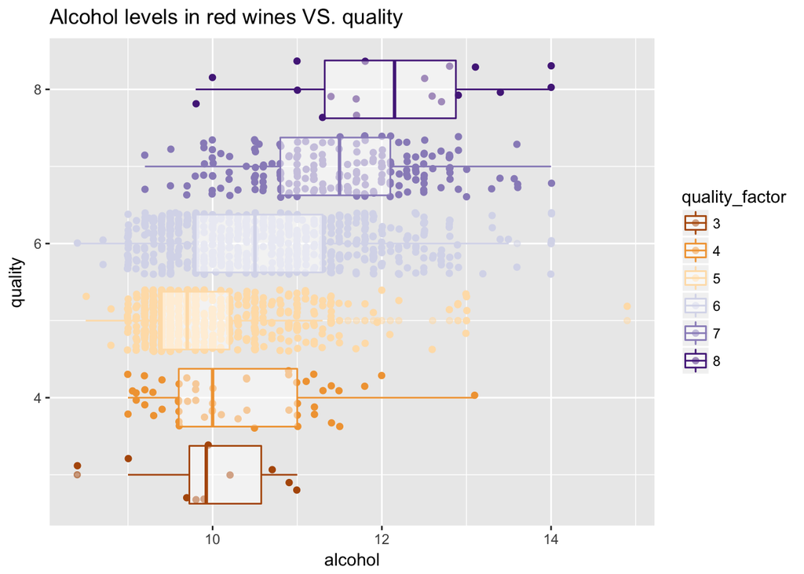

> By plotting the alcohol and quality, we can see better quality red wines tends to have higher alcohol levels. For average and good wines (rated more than 4), the mean of alhocol levels increases with the ranking categories.

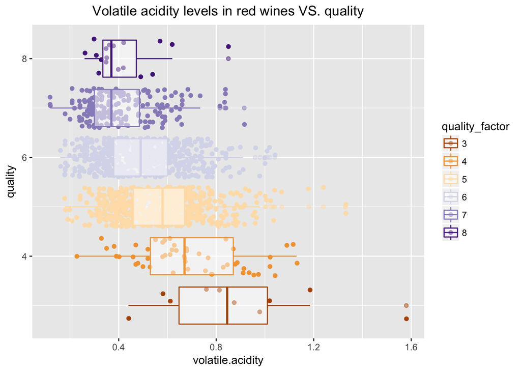

> Good wine tends to have low volatile acidity.

> The third chemical property we try to plot is citric.acid. It is the third/fourth variable that relates to quality, and it is also strongly related to volatile.acidity. We would first provide bivariate plot of citric.acid and quality, and in the next section, further investgate the multi-variable relationship among quality and citric.acid and volatile.acidity.

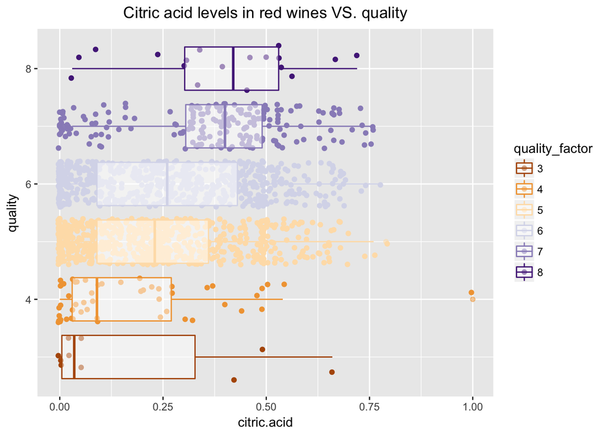

> Good wine tends to have higher citric acid.

# Multivariate Plots and Analysis Section

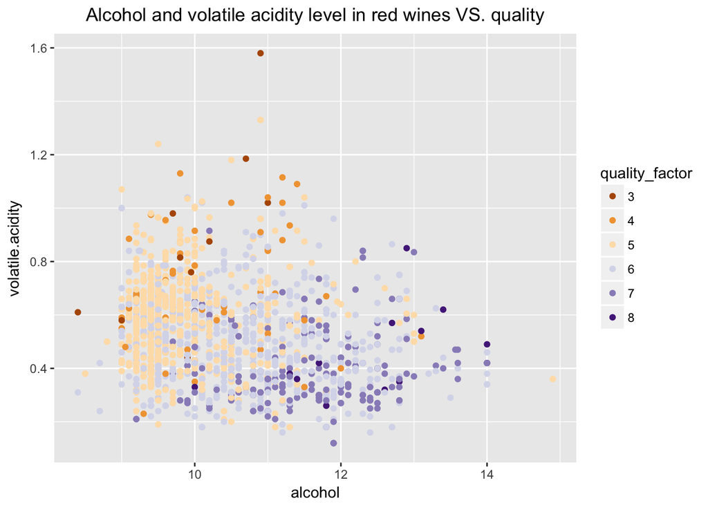

> The first multivariable plot is a point plot, using the two most strongest properties, alcohol and volatile acidity as axis and quality as color to highlight the distribution of different categories of wines. The majority of good wines lie in the zone of higher alcohol value and lower volatile acidity value. While the bad wines are the opposite case.

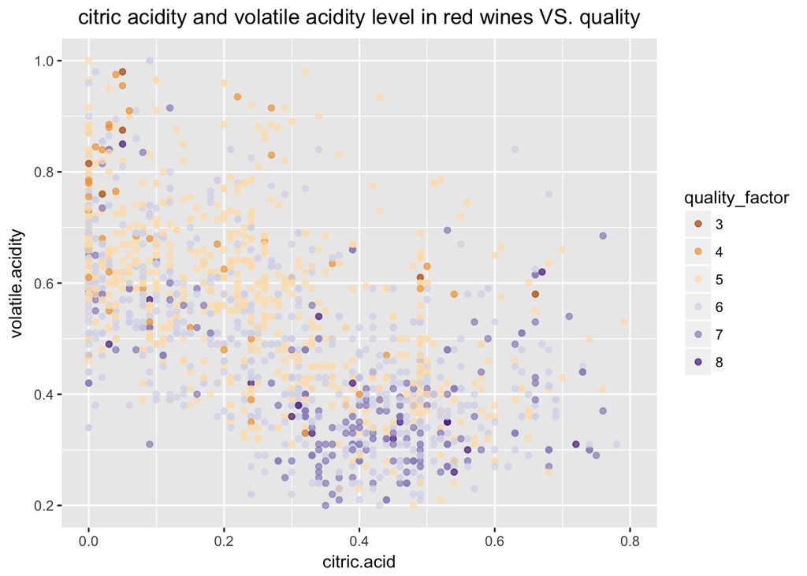

[figure not shown]

# Final Plots and Summary

> To summary this report, we select three presentive plots, an one-variable plot showing the distribution of wine quality, a bi-variable plot showing how a chemical property influences the wine quality, and a multi-variable plot showing how chemical propoerties influnces the wine quality and also how they relate to each other.

### Plot One

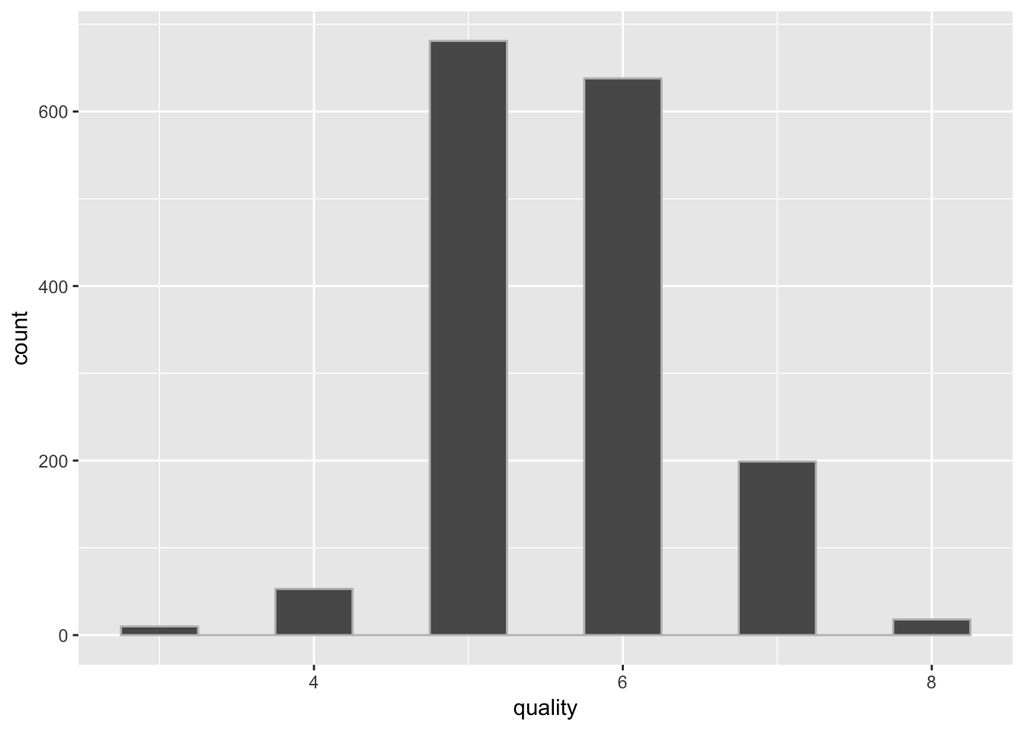

> This first plot gives an overview of wine quality distribution. Wine quality distribution is close to normal distibution, and it is as we expect: the majority of wines on the market are average, very good and very bad wines are few.

### Plot Two

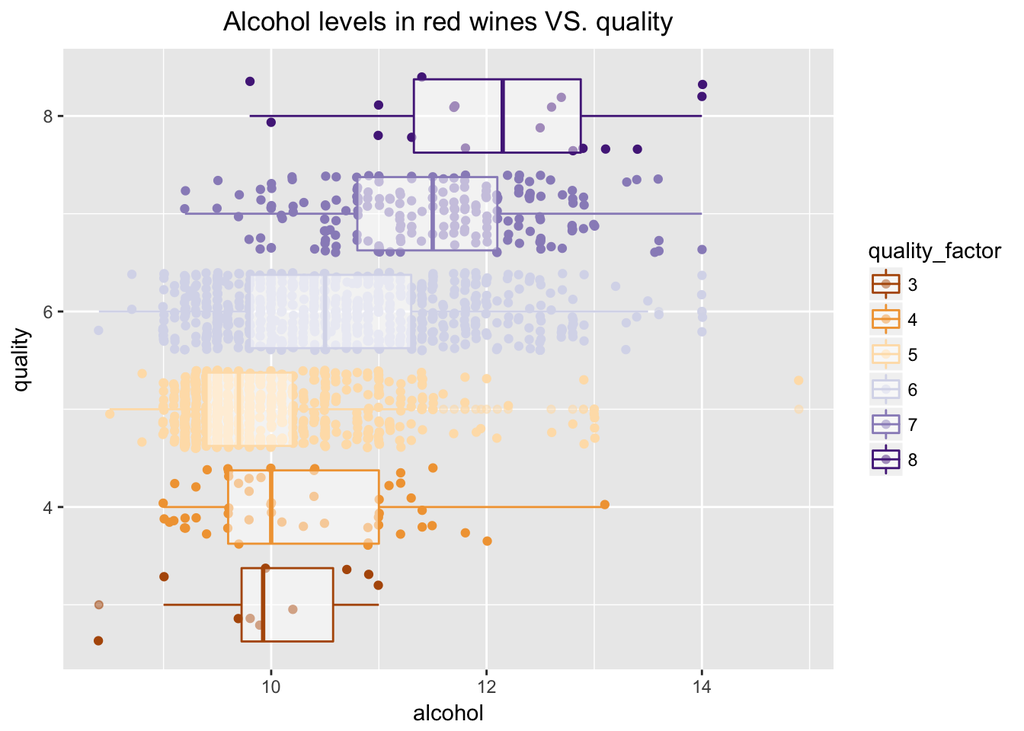

> The second plot shows how one of the most strongly influencing chemical property,alcohol, affects the wine quality. Good wines tend to have a high alcohol level in generel.

### Plot Three

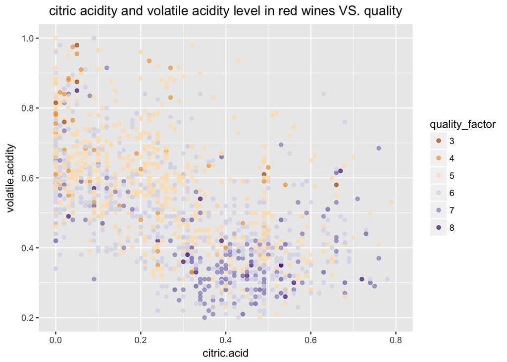

> The thid plot shows how citric acid and volatile acidity influence the wine quality. Moreover these two variable is also related to each other.

# Reflection

> The most different part when starting the analysis is to decide starting from which variable. I wasted some time at the beginner while trying to plot insightful figures. Generating a corrlation matrix among variable, or using ggpair library to analysis a subset of the dataset in advance of bi/multi-variable plotting is very useful.

> Wine tasting is a personal thing. Some people perfer some kinds of wines while the others have different opinions. One future work on the dataset analysis could be, storing deperately the rating from different experts, and then to identify what is the common chemical properties of good wine for each individual. Thus, we can recommend good wine based on similar personal preference, rather than average opinions of some experts.